# Email Marketing Campaign Analysis

## Data Visulaization & Insights

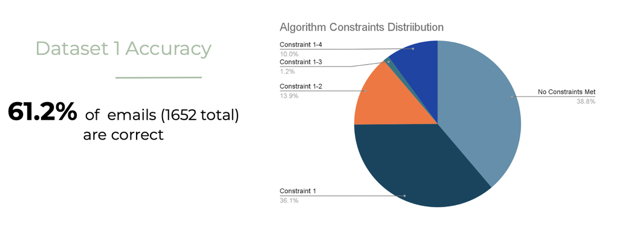

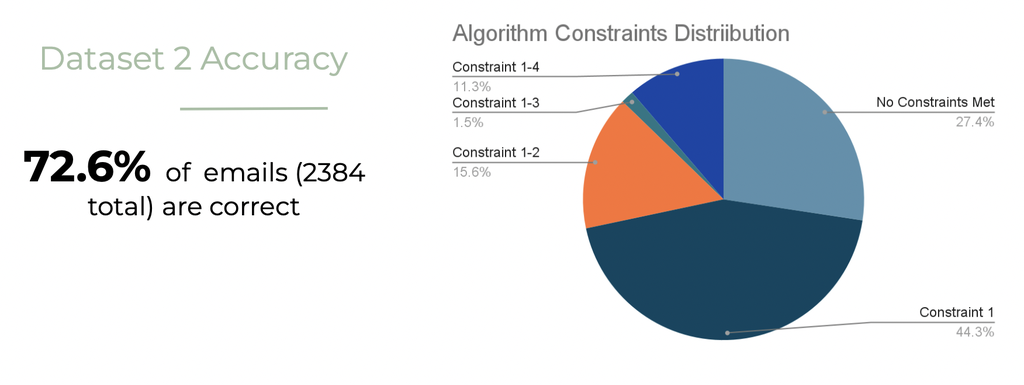

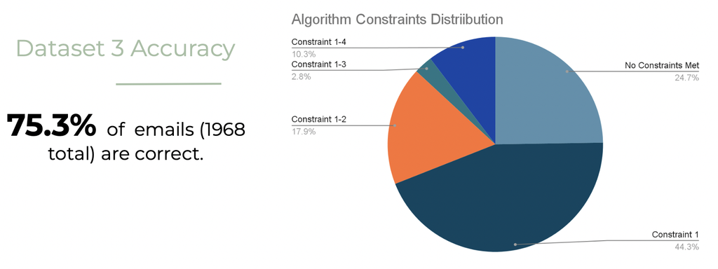

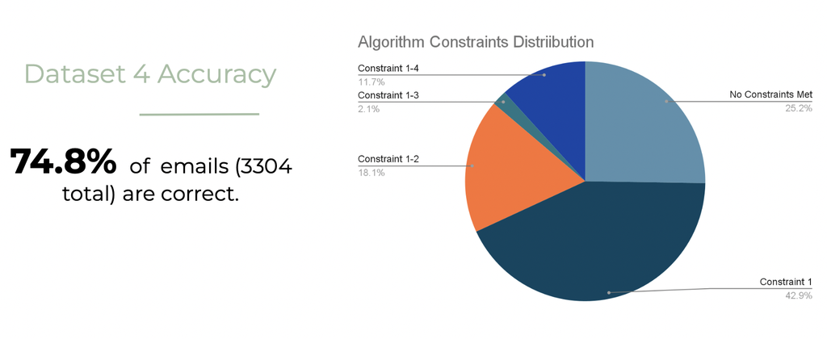

[figure not shown]

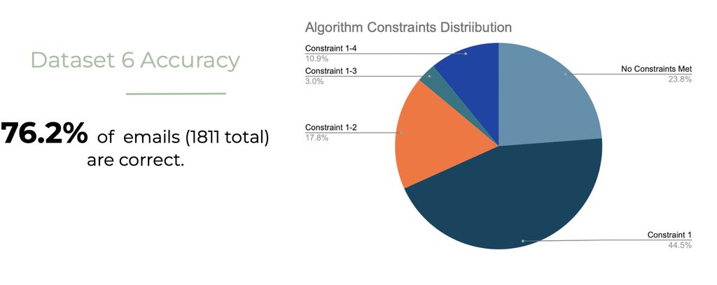

# Diagnostic Analysis

Additionally, the algorithm could, at most, have five constraints with the available attributes. This is one of our limitationsin this project. With more attributes, the algorithm’s accuracy can be significantly improved and the false negatives can also be reduced.

Below are a few emails the algorithm declared incorrect because it did not pass any constraints.

Incorrect Emails

| username | email | phone | splitted_fullname_list | num_chars | string_match | points | constraintsMet |
| --- | --- | --- | --- | --- | --- | --- | --- |
| nicolepacent | nicole.pacent@gmail.com | NA | nicolepacent | 1 | 0 | 0 | 0 |
| pawsomepitbulls | legal@groovebohemia.com | NA | pawesome, pitbulls | 2 | 0 | 0 | 0 |
| andymathisdvm | granitehillsvet@gmail.com | 17062136155 | dr. , andy , mathis | 3 | 0 | 0 | 0 |
| positivephysicaltherapy | positiveptbody@gmail.com | 13107707586 | positivephysicaltherapy | 1 | 0 | 0 | 0 |
| slaphappy563 | slappycolorado@gmail.com | NA | slaphappy563 | 1 | 0 | 0 | 0 |
| spreadtherumer | sian8@charter.net | NA | spreadtherumer, , # , for , feature | 5 | NA | 0 | 0 |

In the table above, we can see a few false negative instances. For example, in the first and fourth entities, based on splitted_fullname_list and username, we can see that the emails have a good chance of being correct; however, the algorithm did not detect any similarities present. This is because the algorithm needs to be more intelligent to compare similarities between names and email addresses. In the first entity, the algorithm takes the full name and compares it to the email because space does not exist to separate the full name. Because the splitted full name does not entirely match that of the email, it returns false and does not pass the first constraint. Similarly, the entire username is not in the email, so it declares false even though the human eye sees some similarities. In the fourth entity, the email includes ‘pt’ as its abbreviation for ‘physical therapy.’ However, because the algorithm is not intelligent enough, it cannot detect word abbreviations that a human can detect, so the algorithm returns false.

The current algorithm is not very accurate, and there is no way for it to be as accurate as a human because no matter how many constraints we add, the algorithm will not be as intelligent as a human. As mentioned in the above paragraph, the algorithm cannot correctly identify all the possibilities because some instances are apparent to humans but are not obvious or cannot be made evident to an algorithm. Therefore, the best practice is using this algorithm on large datasets to identify all the emails in which the algorithm has 100% confidence. For those instances that the algorithm believes to be false, we can use human labor to check for any false negatives. This is the most efficient and accurate way of approaching the problem because we have drastically narrowed the problem.

# Prescriptive Analysis

Previous literature on email marketing and customer behavior suggests that email marketing is increasingly recognized as an effective internet marketing tool (GhavamiLahiji and Abbas (2016)). Tests and studies reveal that email marketing can affect consumer behavior, even convincing consumers to go to websites for more information or to make a purchase (Pulevska Ivanovska and Karadakoska (2015)).

Many literature reviews have been conducted that study the success factors of email marketing. For example, an email marketing study claimed that studying customers’ email open and purchase behaviors is necessary because studying only one can be misleading. Their empirical study shows that some very active email openers are the least active in their purchase behaviors. In addition, some email-inactive customers are relatively active in their purchase behaviors (Zhang, Kumar, and Cosguner (2017)). Thus, if firms focus solely on the email open rate to allocate their resources, they might overlook a pool of customers who are inactive in responding to emails but are relatively active in purchases.

Another study emphasized the importance of personalized email marketing. Consumers are overloaded with information, both wanted and unwanted. In fact, spam accounts for 88% of all email traffic. Adding consumer-specific information (e.g., recipient’s name) can be beneficial for consumers to open marketing emails and not mark them spam. The study ran an experiment and found that adding the name of the message recipient to the email’s subject line increased the probability of the recipient opening it by 20%, which translated to an increase in sales leads by 31% and a reduction in the number of individuals unsubscribing from the email campaign by 17% (Pavlov, Melville, and Plice (2008)). This indicates that email personalization can lead to acquiring more customers and retaining previous customers.

In addition to personalized marketing, some studies found permission email marketing (PEM) to positively influence online shopping behavior (Sahni, Wheeler, and Chintagunta (2018)). The results of the studies indicate that PEM affects the perceived usefulness, ease of use, and enjoyment derived from shopping online. It also serves to reduce the perceived risk (Mogos and Acatrinei (2015)).

A model designed by a study on the success factors of email marketing suggests that there are three stages in effective email marketing (Rettie (2017)):

- getting the recipient to open the email
- getting them to pay attention to the email
- persuading them to click through the URL link

Hence, the response rate should depend on the email header in the inbox, the email contents, and the recipient.

The same study researched 30 email marketing campaigns and found factors, such as subject line, email length, incentive, and the number of images, to be associated with increased response rate. Additionally, the study conducted a regression analysis in which they discovered the following correlations.

- Higher response rates correlate with more attractive email subject lines.
- Higher response rates correlate with more attractive incentives.
- Response rate is inversely related to the email length.
- Higher response rates correlate with more images.
- Higher response rates correlate with emails from well-known brands.
- Permission email has higher response rates.
- Response rates are higher for respondents who receive fewer emails.
- Response rate is higher for HTML than text messages.
- Respondents who have used the Internet for longer are more likely to respond.
- Elderly consumers do not prefer email marketing methods for daily purchases. Whereas, younger consumers prefer using email marketing methods for daily purchases.
- Female consumers prefer using “Email marketing” methods for daily purchases.
- Consumers with higher education prefer to use “Email marketing.”
- People with lower education levels tend to prefer “Email marketing” less for their daily purchases than those with a higher education levels.
- Higher responses were recorded for respondents who had bought online, aged 30 -34, or with incomes over £35,000.

In conclusion, if the Fintech startup implements some of the suggestions mentioned in this section, they can significantly improve their email marketing strategy leading to higher customer acquisition and retention.

# Bibliography

GhavamiLahiji, Shiva, and Bandar Abbas. 2016. “The Effect of Email Marketing on Buyers’ Behavior.” In.

Gilbertson, David. 2019. “The 100.” *Medium*. HackerNoon.com. https://medium.com/hackernoon/the-100-correct-way-to-validate-email-addresses-7c4818f24643.

Harper, Drew. 2022. “12 Solid Facts and Stats About Email Marketing You Should Know.” *WHSR*. https://www.webhostingsecretrevealed.net/blog/ecommerce/email-marketing-stats-facts/.

Kimixay, Litinthong, Liu Cheng, and Liu Xiangdong. 2019. “An Empirical Study to Understand the Effect of Email Marketing on Consumer’s Online Buying Behavior in a Developing Country.” In *Proceedings of the 2019 3rd International Conference on Management Engineering, Software Engineering and Service Sciences*, 179–83. ICMSS 2019. New York, NY, USA: Association for Computing Machinery. https://doi.org/10.1145/3312662.3312669.

Mogos, Radu, and Carmen Acatrinei. 2015. “Designing Email Marketing Campaigns - a Data Mining Approach Based on Consumer Preferences.” *Annales Universitatis Apulensis Series Oeconomica* 1 (June): 15–30. https://doi.org/10.29302/oeconomica.2015.17.1.1.

Pavlov, Oleg V., Nigel Melville, and Robert K. Plice. 2008. “Toward a Sustainable Email Marketing Infrastructure.” *Journal of Business Research* 61 (11): 1191–9. https://doi.org/https://doi.org/10.1016/j.jbusres.2007.11.010.

Pulevska Ivanovska, Lidija, and Elena Karadakoska. 2015. “Impact of E-Marketing on Consumer Behavior.” *Ekonomski Pogledi* 17 (January): 67–81. https://doi.org/10.5937/EkoPog1504067P.

Rettie, Ruth. 2017. “Email Marketing: Success Factors.” *Kington Business School*.

Sahni, Navdeep S., S. Christian Wheeler, and Pradeep Chintagunta. 2018. “Personalization in Email Marketing: The Role of Noninformative Advertising Content.” *Marketing Science* 37 (2): 236–58. https://doi.org/10.1287/mksc.2017.1066.

Statista. 2021. “Number of Sent and Received E-Mails Per Day Worldwide from 2017 to 2025 (in Billions).” *Statista*. https://www.statista.com/statistics/45650 0/daily-number-of-e-mails-worldwide/.

Subramania, and Jeshurun Bala. 2018. “A Study on the Effectiveness of Email Marketing.” Management for Strategic Business Ideas. CMA Canada. https://www.shanlax.com/wp-content/uploads/SIJ_MGT_Oct2018_V6_N1_018.pdf.

Wolfe, John. 2017. “Direct Media Response Rate, Cpa & Roi Benchmarks in 2017.” *Marketing Charts*. https://www.marketingcharts.com/digital-78422.

Zhang, Xi (Alan), V. Kumar, and Koray Cosguner. 2017. “Dynamically Managing a Profitable Email Marketing Program.” *Journal of Marketing Research* 54 (6): 851–66. https://doi.org/10.1509/jmr.16.0210.